# Chapter 3 Bar Graphics

Toan

2016年4月16日

3.1 Making the Basic Bar Graphics.

```r
library(ggplot2)
library(gcookbook)
pg_mean
```

```
##   group weight
## 1  ctrl  5.032
## 2  trt1  4.661
## 3  trt2  5.526
```

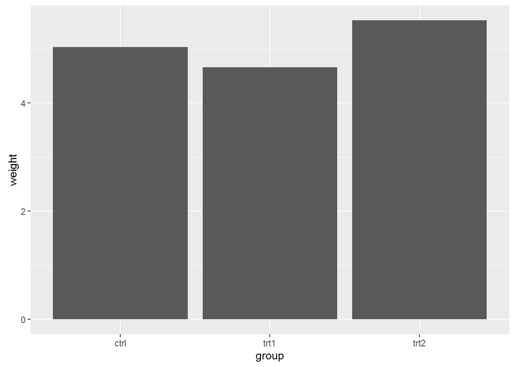

```r
ggplot(pg_mean, aes(x = group, y = weight)) + geom_bar(stat = "identity")
```

```r
# x as continuos and x as factor.
BOD
```

```
##   Time demand
## 1    1    8.3
## 2    2   10.3
## 3    3   19.0
## 4    4   16.0
## 5    5   15.6
## 6    7   19.8
```

```r
str(BOD)
```

```
## 'data.frame':    6 obs. of  2 variables:
##  $ Time  : num  1 2 3 4 5 7
##  $ demand: num  8.3 10.3 19 16 15.6 19.8
##  - attr(*, "reference")= chr "A1.4, p. 270"
```

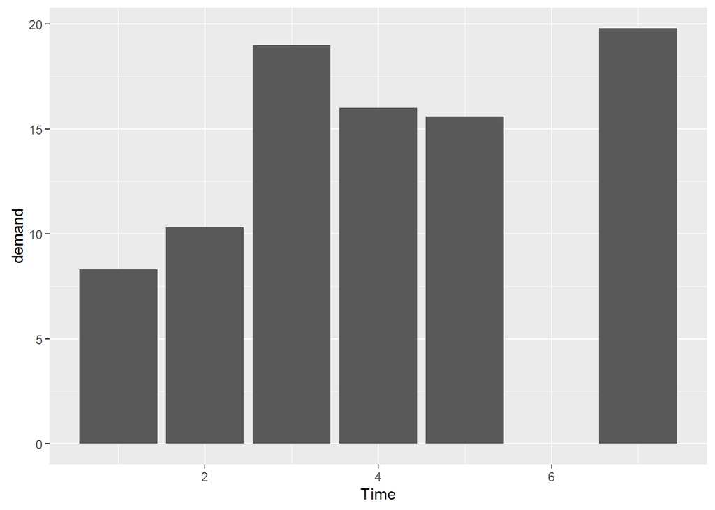

```r
ggplot(BOD, aes(x = Time, y = demand)) + geom_bar(stat = "identity")
```

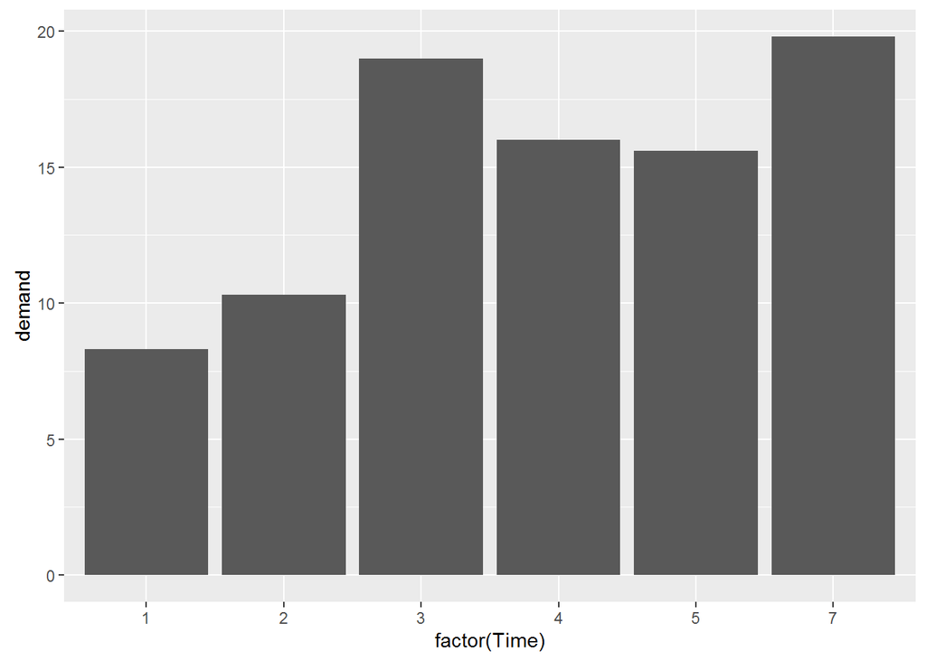

```r
ggplot(BOD, aes(x = factor(Time), y = demand)) + geom_bar(stat = "identity")
```

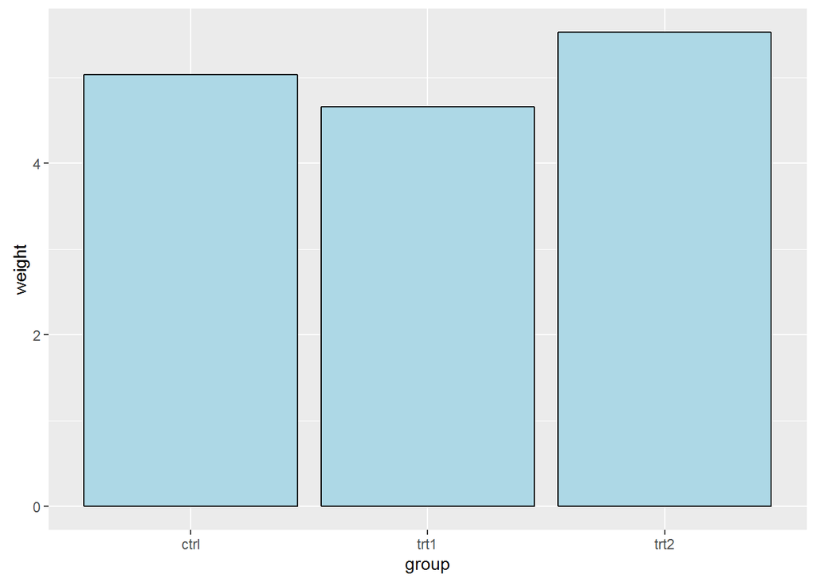

```r
# change fill colour (fill) and outline (colour)
ggplot(pg_mean, aes(x = group, y = weight))+ geom_bar(stat = "identity", fill = "lightblue", colour = "black")
```

3.2. Grouping Bars Together

```r
library(gcookbook) # For the data set
cabbage_exp
```

```
##   Cultivar Date Weight        sd  n         se
## 1      c39  d16   3.18 0.9566144 10 0.30250803
## 2      c39  d20   2.80 0.2788867 10 0.08819171
## 3      c39  d21   2.74 0.9834181 10 0.31098410
## 4      c52  d16   2.26 0.4452215 10 0.14079141
## 5      c52  d20   3.11 0.7908505 10 0.25008887
## 6      c52  d21   1.47 0.2110819 10 0.06674995
```

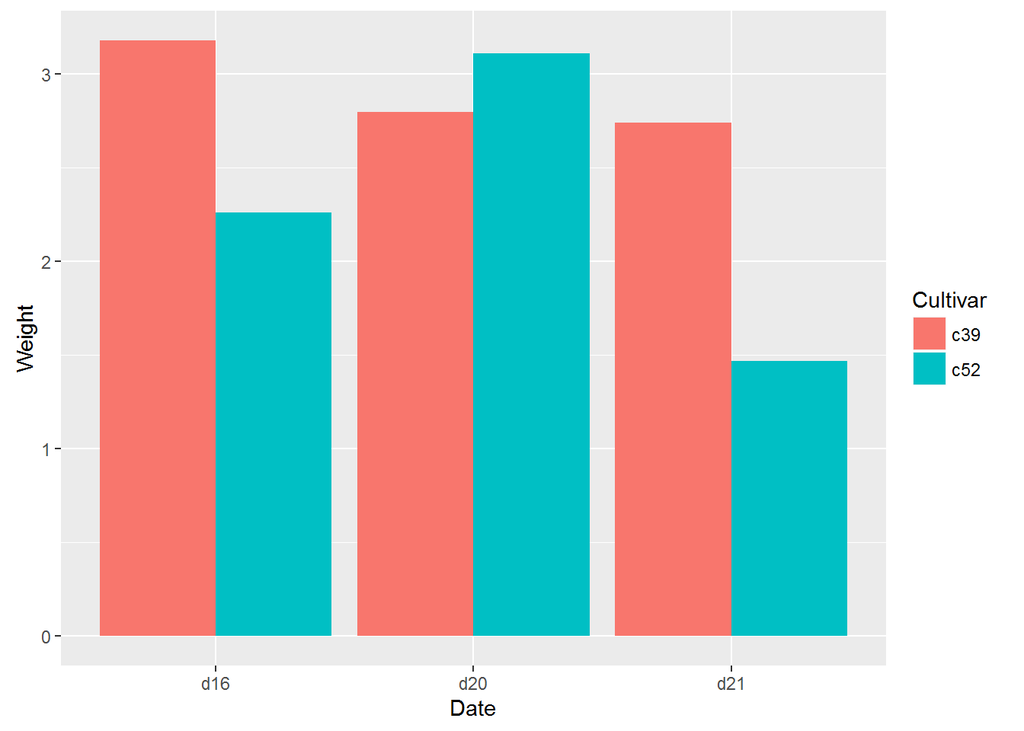

```r
ggplot(cabbage_exp, aes(x=Date, y=Weight, fill=Cultivar)) +
 geom_bar(stat = "identity", position="dodge")
```

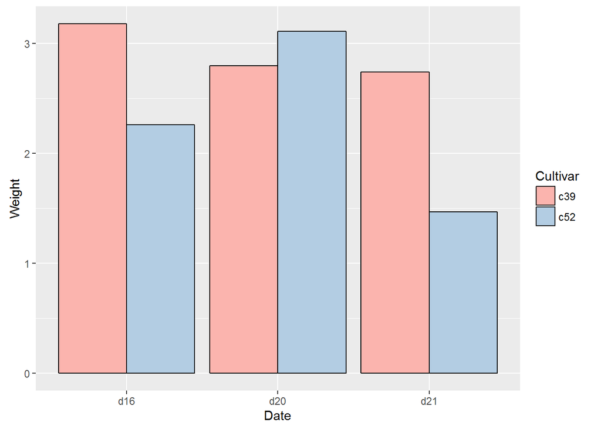

```r
# Change the colour templete (scale_fill_brewer(palette="Pastel1"))
ggplot(cabbage_exp, aes(x=Date, y=Weight, fill=Cultivar)) +
  geom_bar(stat = "identity", position="dodge", colour="black") +
  scale_fill_brewer(palette="Pastel1")
```

3.3. Making a Bar Graph of Counts

```r
# Marking a graphing of count ( x only)
head(diamonds)
```

```
##   carat       cut color clarity depth table price    x    y    z
## 1  0.23     Ideal     E     SI2  61.5    55   326 3.95 3.98 2.43
## 2  0.21   Premium     E     SI1  59.8    61   326 3.89 3.84 2.31
## 3  0.23      Good     E     VS1  56.9    65   327 4.05 4.07 2.31
## 4  0.29   Premium     I     VS2  62.4    58   334 4.20 4.23 2.63
## 5  0.31      Good     J     SI2  63.3    58   335 4.34 4.35 2.75
## 6  0.24 Very Good     J    VVS2  62.8    57   336 3.94 3.96 2.48
```

```r
str(diamonds)
```

```
## Classes 'tbl_df', 'tbl' and 'data.frame':    53940 obs. of  10 variables:
##  $ carat  : num  0.23 0.21 0.23 0.29 0.31 0.24 0.24 0.26 0.22 0.23 ...
##  $ cut    : Ord.factor w/ 5 levels "Fair"<"Good"<..: 5 4 2 4 2 3 3 3 1 3 ...
##  $ color  : Ord.factor w/ 7 levels "D"<"E"<"F"<"G"<..: 2 2 2 6 7 7 6 5 2 5 ...
##  $ clarity: Ord.factor w/ 8 levels "I1"<"SI2"<"SI1"<..: 2 3 5 4 2 6 7 3 4 5 ...
##  $ depth  : num  61.5 59.8 56.9 62.4 63.3 62.8 62.3 61.9 65.1 59.4 ...
##  $ table  : num  55 61 65 58 58 57 57 55 61 61 ...
##  $ price  : int  326 326 327 334 335 336 336 337 337 338 ...
##  $ x      : num  3.95 3.89 4.05 4.2 4.34 3.94 3.95 4.07 3.87 4 ...
##  $ y      : num  3.98 3.84 4.07 4.23 4.35 3.96 3.98 4.11 3.78 4.05 ...
##  $ z      : num  2.43 2.31 2.31 2.63 2.75 2.48 2.47 2.53 2.49 2.39 ...
```

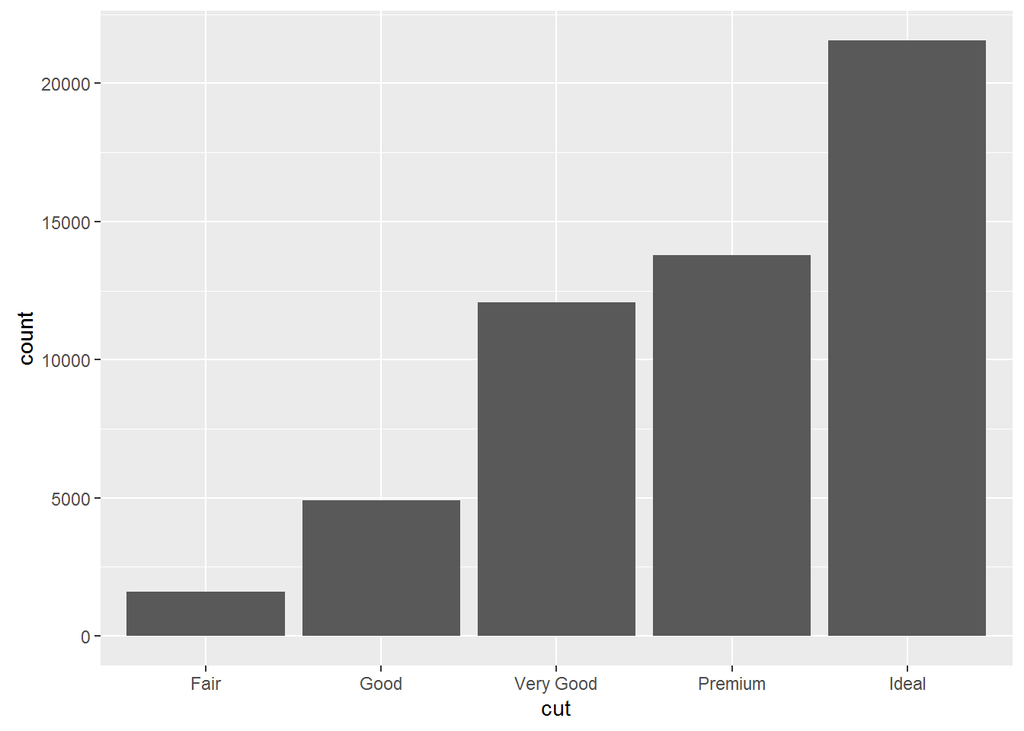

```r
ggplot(diamonds, aes(x = cut)) + geom_bar()
```

3.4. Using Colors in a Bar Graph

```r
library(gcookbook) # For the data set
upc <- subset(uspopchange, rank(Change)>40)
upc
```

```
##             State Abb Region Change
## 3         Arizona  AZ   West   24.6
## 6        Colorado  CO   West   16.9
## 10        Florida  FL  South   17.6
## 11        Georgia  GA  South   18.3
## 13          Idaho  ID   West   21.1
## 29         Nevada  NV   West   35.1
## 34 North Carolina  NC  South   18.5
## 41 South Carolina  SC  South   15.3
## 44          Texas  TX  South   20.6
## 45           Utah  UT   West   23.8
```

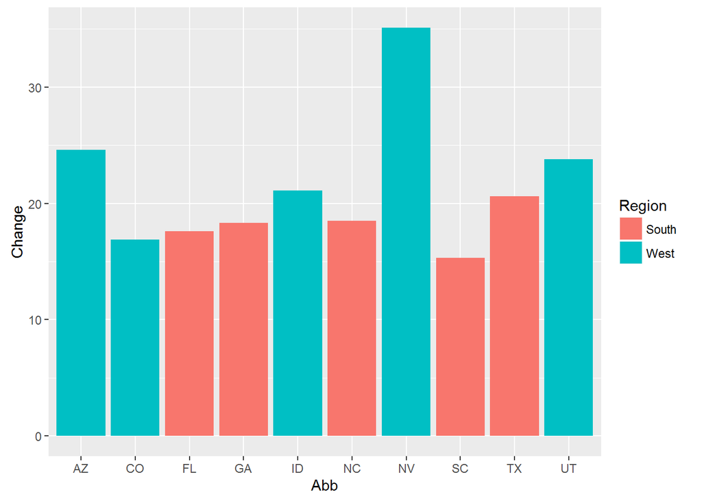

```r
ggplot(upc, aes(x=Abb, y=Change, fill=Region)) + geom_bar(stat="identity")
```

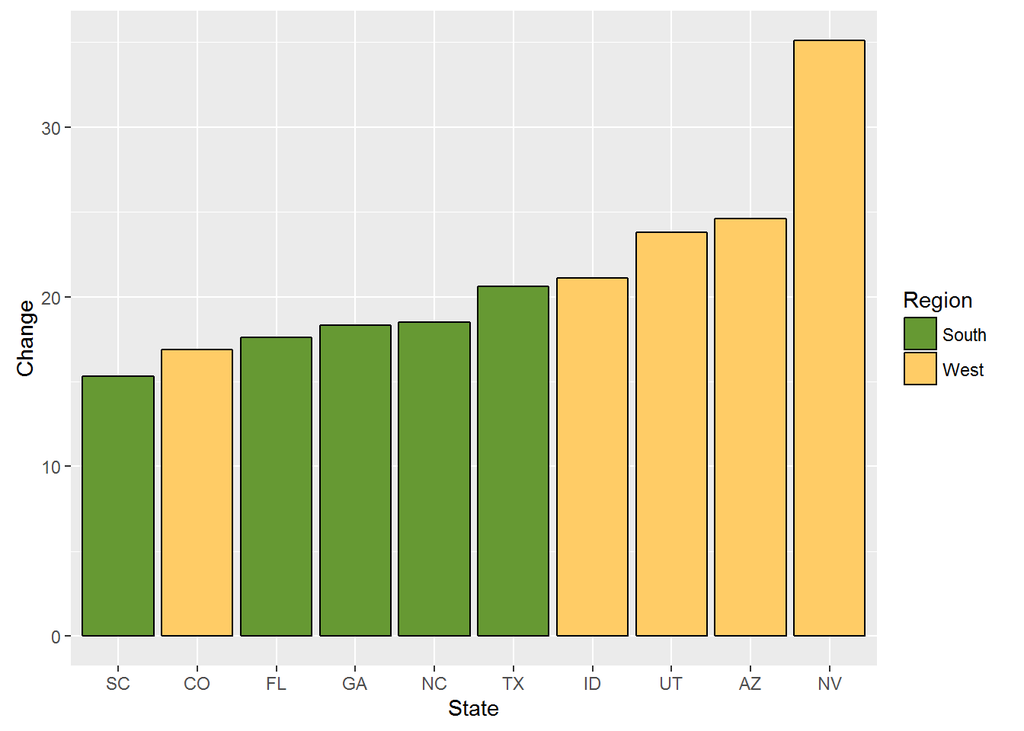

```r
ggplot(upc, aes(x=reorder(Abb, Change), y=Change, fill=Region)) +
geom_bar(stat="identity", colour="black") +
scale_fill_manual(values=c("#669933", "#FFCC66")) +
xlab("State")
```

```r
#Comment: Change the colour of the bar chart by using scale_fill_manual
```

3.5. Coloring Negative and Positive Bars Differently

```r
library(gcookbook) # For the data set
csub <- subset(climate, Source=="Berkeley" & Year >= 1900)
csub$pos <- csub$Anomaly10y >= 0
csub
```

```
##       Source Year Anomaly1y Anomaly5y Anomaly10y Unc10y   pos
## 101 Berkeley 1900        NA        NA     -0.171  0.108 FALSE
## 102 Berkeley 1901        NA        NA     -0.162  0.109 FALSE
## 103 Berkeley 1902        NA        NA     -0.177  0.108 FALSE
## 104 Berkeley 1903        NA        NA     -0.199  0.104 FALSE
## 105 Berkeley 1904        NA        NA     -0.223  0.105 FALSE
## 106 Berkeley 1905        NA        NA     -0.241  0.107 FALSE
## 107 Berkeley 1906        NA        NA     -0.294  0.106 FALSE
## 108 Berkeley 1907        NA        NA     -0.312  0.105 FALSE
## 109 Berkeley 1908        NA        NA     -0.328  0.103 FALSE
## 110 Berkeley 1909        NA        NA     -0.281  0.101 FALSE
## 111 Berkeley 1910        NA        NA     -0.247  0.099 FALSE
## 112 Berkeley 1911        NA        NA     -0.243  0.097 FALSE
## 113 Berkeley 1912        NA        NA     -0.257  0.100 FALSE
## 114 Berkeley 1913        NA        NA     -0.268  0.100 FALSE
```

[output cut: 91 more lines]

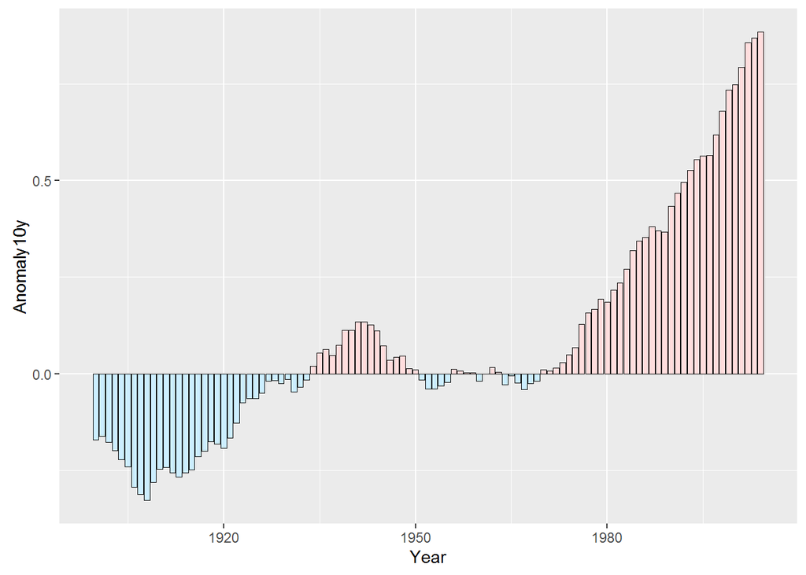

```r
ggplot(csub, aes(x=Year, y=Anomaly10y, fill=pos)) +
geom_bar(stat="identity", position="identity", colour="black", size=0.25) +
scale_fill_manual(values=c("#CCEEFF", "#FFDDDD"), guide=FALSE)
```

```r
#Comment: create one more variable pos( TRUE OR FAIL) and use fill the map the colour
```

3.6. Adjusting Bar Width and Spacing

For grouped bar.

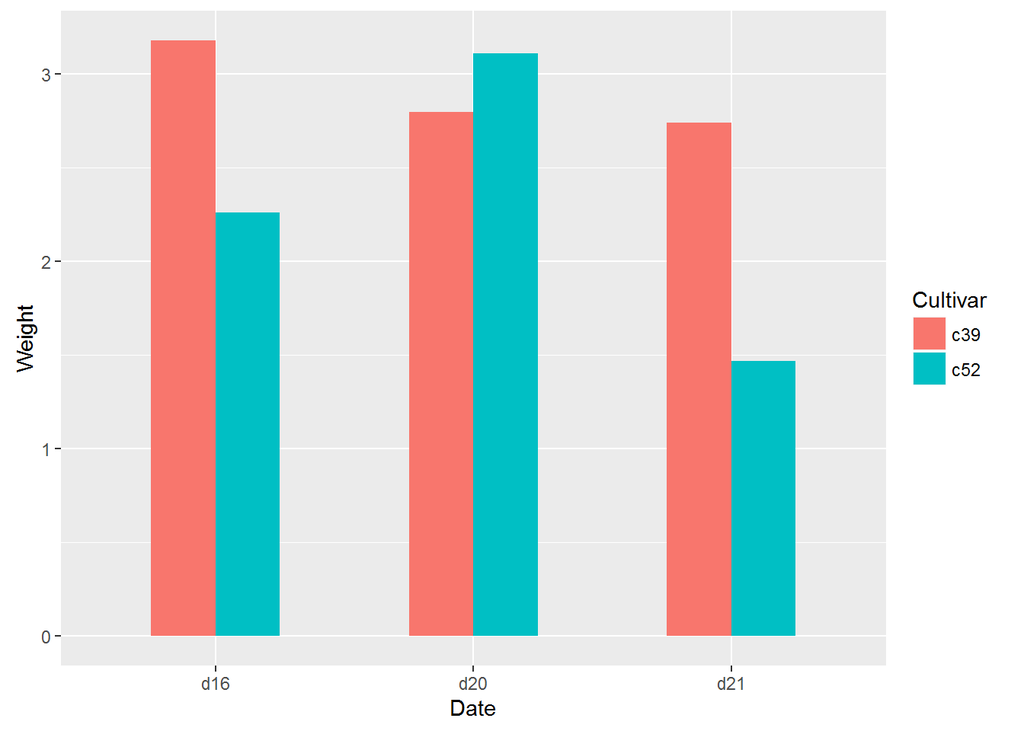

```r
ggplot(cabbage_exp, aes(x=Date, y=Weight, fill=Cultivar)) +
geom_bar(stat="identity", width=0.5, position="dodge")
```

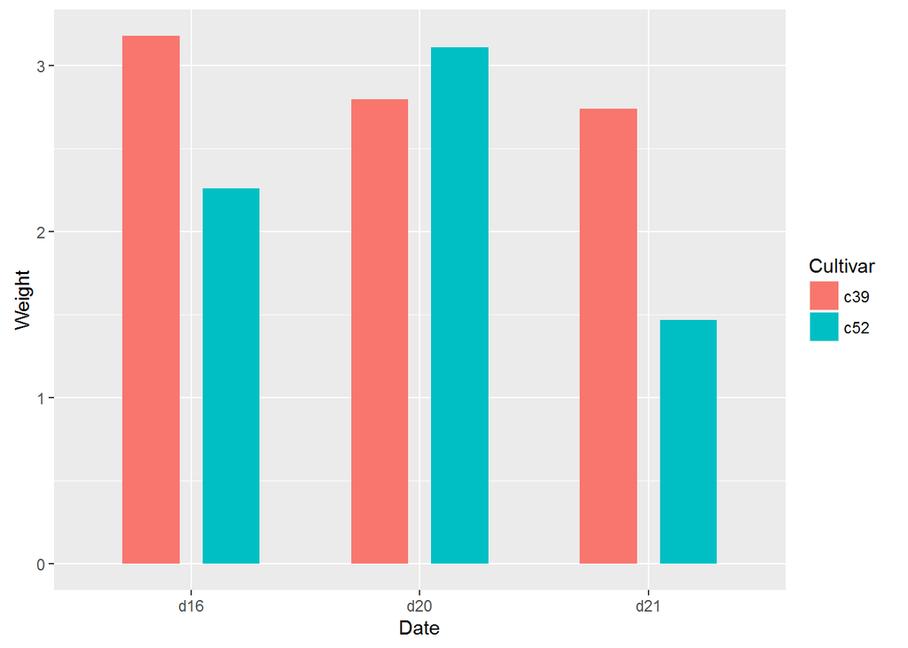

```r
ggplot(cabbage_exp, aes(x=Date, y=Weight, fill=Cultivar)) +
geom_bar(stat="identity", width=0.5, position=position_dodge(0.7))
```

```r
#Comment: by default grouped bar displayed together, set postion_doge > width for seperatation.
```

3.7. Making a Stacked Bar Graph

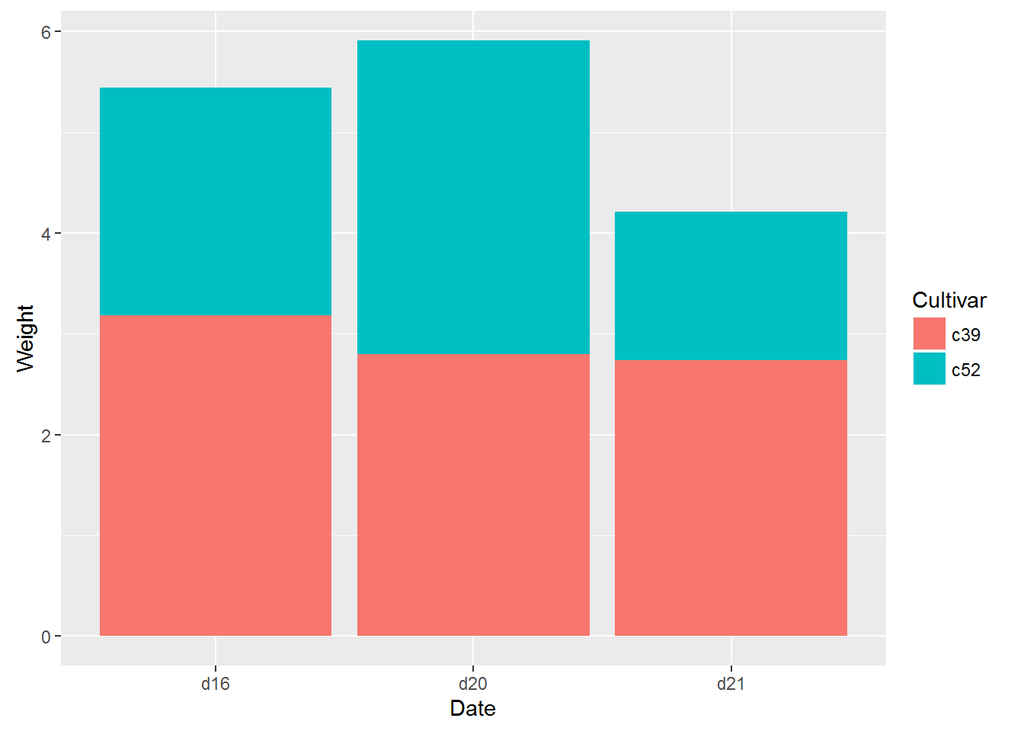

```r
library(gcookbook) # For the data set
ggplot(cabbage_exp, aes(x=Date, y=Weight, fill=Cultivar)) +
geom_bar(stat="identity")
```

```r
# Comment: we can make stacked bar instead of normal bar chart by
#do not specify postion = dodge.
```

Change the lable to the correct position

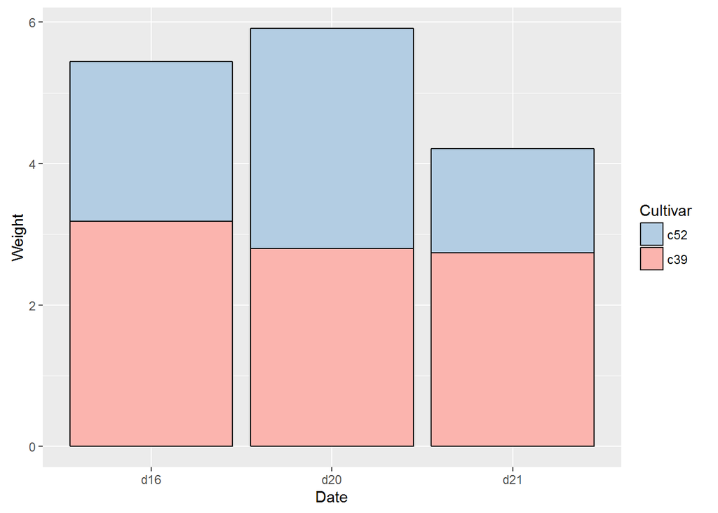

```r
ggplot(cabbage_exp, aes(x=Date, y=Weight, fill=Cultivar)) +
geom_bar(stat="identity", colour="black") +
guides(fill=guide_legend(reverse=TRUE)) +
scale_fill_brewer(palette="Pastel1")
```

```r
# Comment: there are two way to do that. one is specify
#order in aes. two is guides(fill=guide_legend(reverse=TRUE))
```

3.8. Making a Proportional Stacked Bar Graph Need some data manipulation.

```r
library(gcookbook) # For the data set
library(dplyr)
ce <- cabbage_exp %>%
  group_by(Date) %>% mutate(percent_weight = Weight/sum(Weight)*100) %>%
  arrange(Date)
ce
```

```
## Source: local data frame [6 x 7]
## Groups: Date [3]
##
##   Cultivar   Date Weight        sd     n         se percent_weight
##     (fctr) (fctr)  (dbl)     (dbl) (int)      (dbl)          (dbl)
## 1      c39    d16   3.18 0.9566144    10 0.30250803       58.45588
## 2      c52    d16   2.26 0.4452215    10 0.14079141       41.54412
## 3      c39    d20   2.80 0.2788867    10 0.08819171       47.37733
## 4      c52    d20   3.11 0.7908505    10 0.25008887       52.62267
## 5      c39    d21   2.74 0.9834181    10 0.31098410       65.08314
## 6      c52    d21   1.47 0.2110819    10 0.06674995       34.91686
```

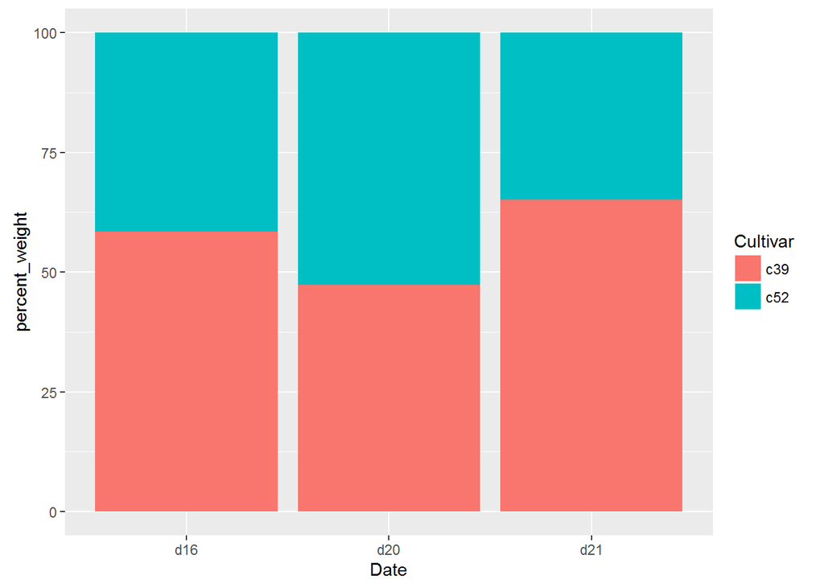

```r
ggplot(ce, aes(x=Date, y=percent_weight, fill=Cultivar)) +
geom_bar(stat="identity")
```

We want to do some thing more.

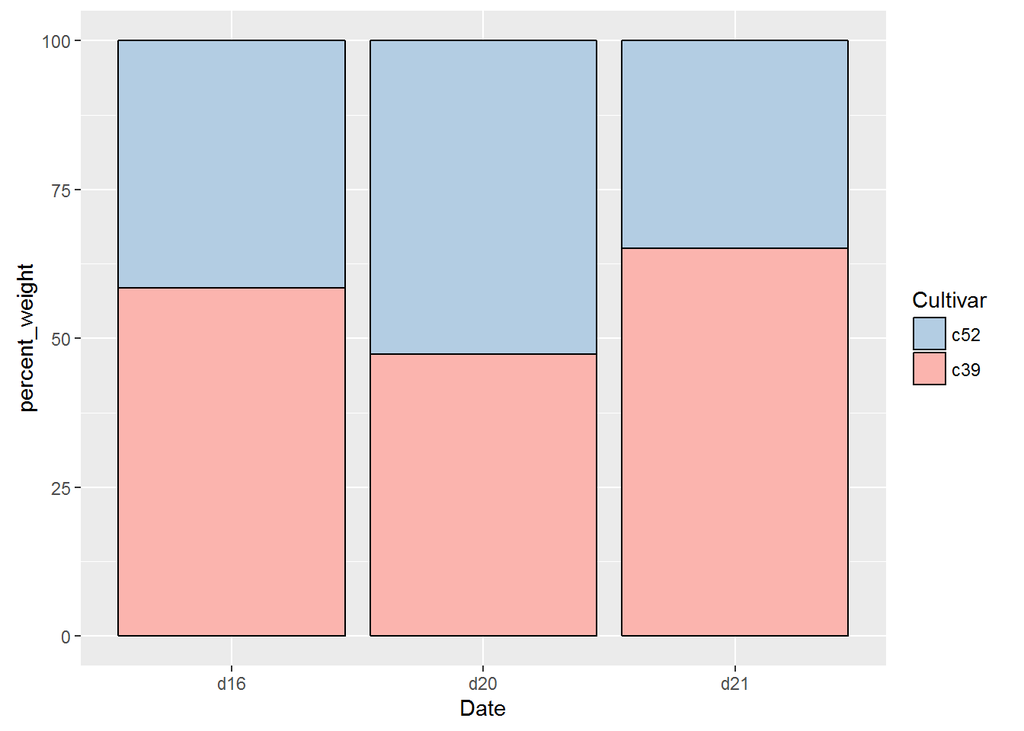

```r
ggplot(ce, aes(x=Date, y=percent_weight, fill=Cultivar)) +
geom_bar(stat="identity", colour="black") +
guides(fill=guide_legend(reverse=TRUE)) +
scale_fill_brewer(palette="Pastel1")
```

```r
# Comment: create outline wiht colour, change lable to correct position
# with guides(fill=guide_legend(reverse=TRUE))
# change default coour by scale_fill_brewer(palette="Pastel1")
```

3.9. Adding Labels to a Bar Graph

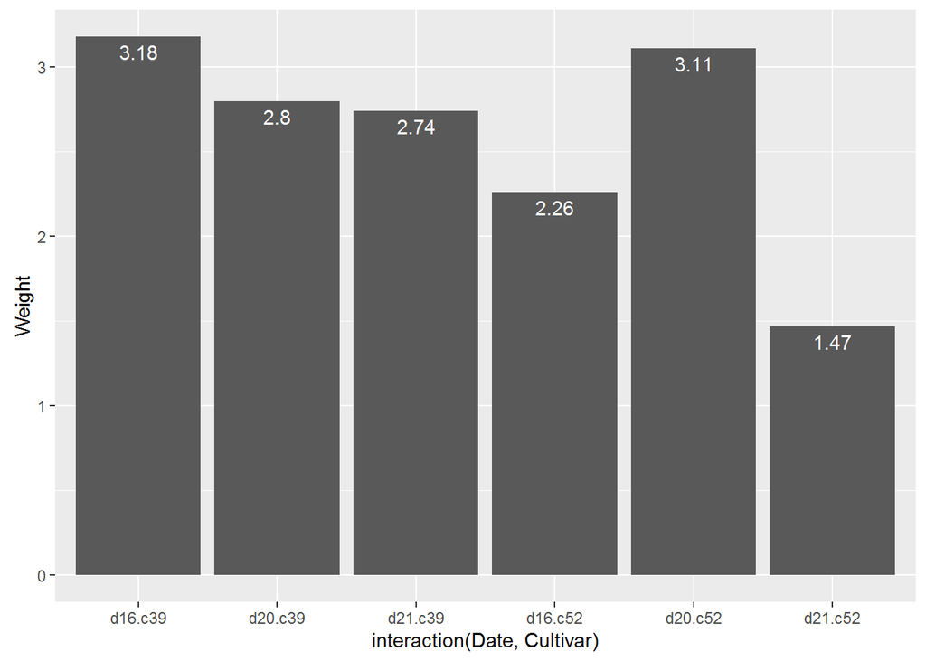

```r
# Below the top
ggplot(cabbage_exp, aes(x=interaction(Date, Cultivar), y=Weight)) +
geom_bar(stat="identity") +
geom_text(aes(label=Weight), vjust=1.5, colour="white")
```

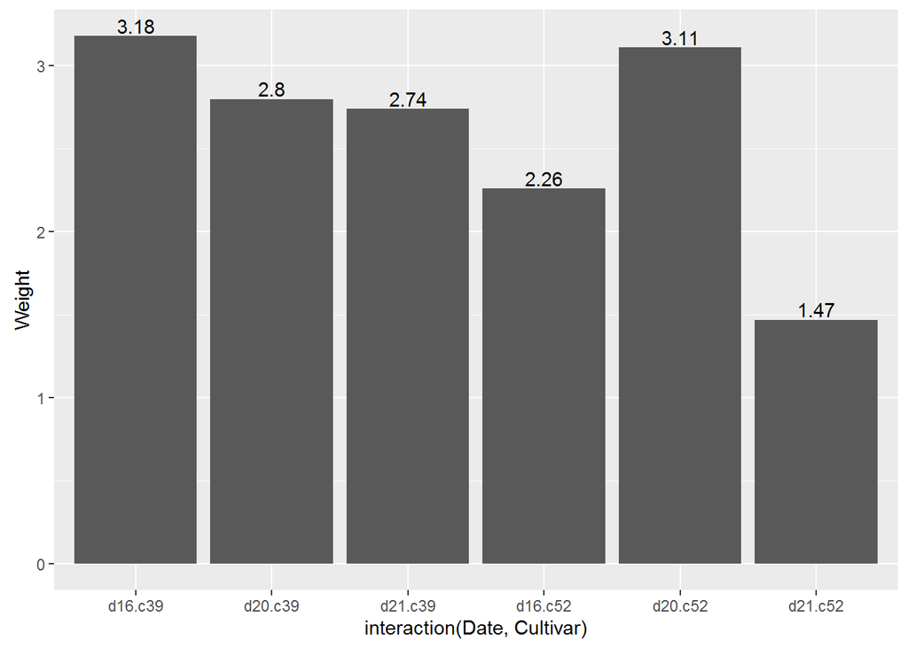

```r
# Above the top
ggplot(cabbage_exp, aes(x=interaction(Date, Cultivar), y=Weight)) +
geom_bar(stat="identity") +
geom_text(aes(label=Weight), vjust=-0.2)
```

```r
#Comment:
```

Adjust y limit to be a little higher

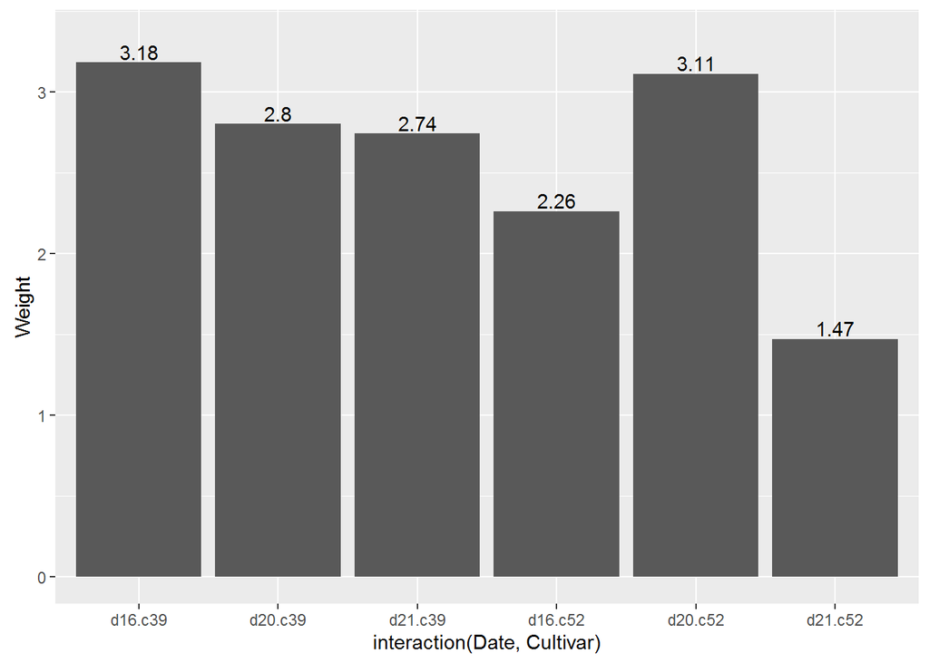

```r
ggplot(cabbage_exp, aes(x=interaction(Date, Cultivar), y=Weight)) +
geom_bar(stat="identity") +
geom_text(aes(label=Weight), vjust=-0.2) +
ylim(0, max(cabbage_exp$Weight) * 1.05)
```

```r
# Comment: we adjust y limit by using
#ylim(0, max(cabbage_exp$Weight) * 1.05)
```

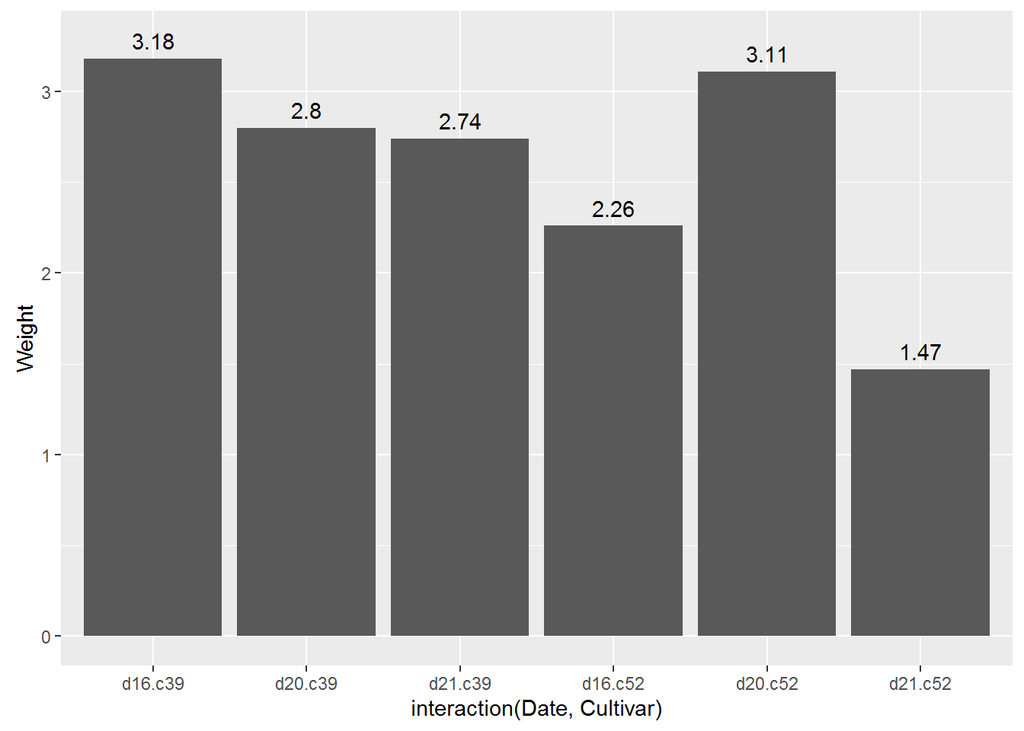

```r
# Map y positions slightly above bar top - y range of plot will auto-adjust
ggplot(cabbage_exp, aes(x=interaction(Date, Cultivar), y=Weight)) +
geom_bar(stat="identity") +
geom_text(aes(y=Weight+0.1, label=Weight))
```

```r
#Comment: by using geom_text(aes(y=Weight+0.1, label=Weight))
```

We want to put the number value in the middle of the bar chart and change to the proper label order.

```r
library(dplyr)
library(ggplot2)
library(gcookbook) #for the data
ce <- cabbage_exp %>% group_by(Date) %>%
  mutate(label_y = cumsum(Weight) - 0.5*Weight)
ce
```

```
## Source: local data frame [6 x 7]
## Groups: Date [3]
##
##   Cultivar   Date Weight        sd     n         se label_y
##     (fctr) (fctr)  (dbl)     (dbl) (int)      (dbl)   (dbl)
## 1      c39    d16   3.18 0.9566144    10 0.30250803   1.590
## 2      c39    d20   2.80 0.2788867    10 0.08819171   1.400
## 3      c39    d21   2.74 0.9834181    10 0.31098410   1.370
## 4      c52    d16   2.26 0.4452215    10 0.14079141   4.310
## 5      c52    d20   3.11 0.7908505    10 0.25008887   4.355
## 6      c52    d21   1.47 0.2110819    10 0.06674995   3.475
```

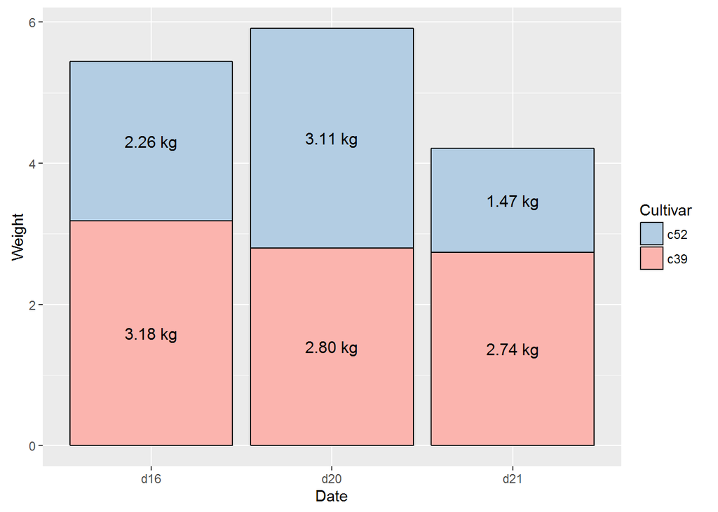

```r
ggplot(ce, aes(x=Date, y=Weight, fill=Cultivar)) +
geom_bar(stat="identity", colour="black") +
  geom_text(aes(y=label_y, label=paste(format(Weight, nsmall=2), "kg")),
size=4) +
guides(fill=guide_legend(reverse=TRUE)) +
scale_fill_brewer(palette="Pastel1")
```

```r
# Comment: We create one more varialbe label_y
# to index the postion of label
# and using geom_text to print text label.
```

3.10 Marking a Cleveland Dot Plot. We want to create normal Cleveland Dot Plot

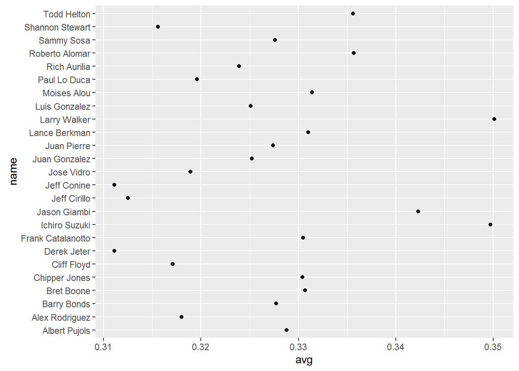

```r
library(gcookbook) # For the data set
tophit <- tophitters2001[1:25, ] # Take the top 25 from the tophitters data set
ggplot(tophit, aes(x=avg, y=name)) + geom_point()
```

We want to reorder the y axis (name by the value in x)

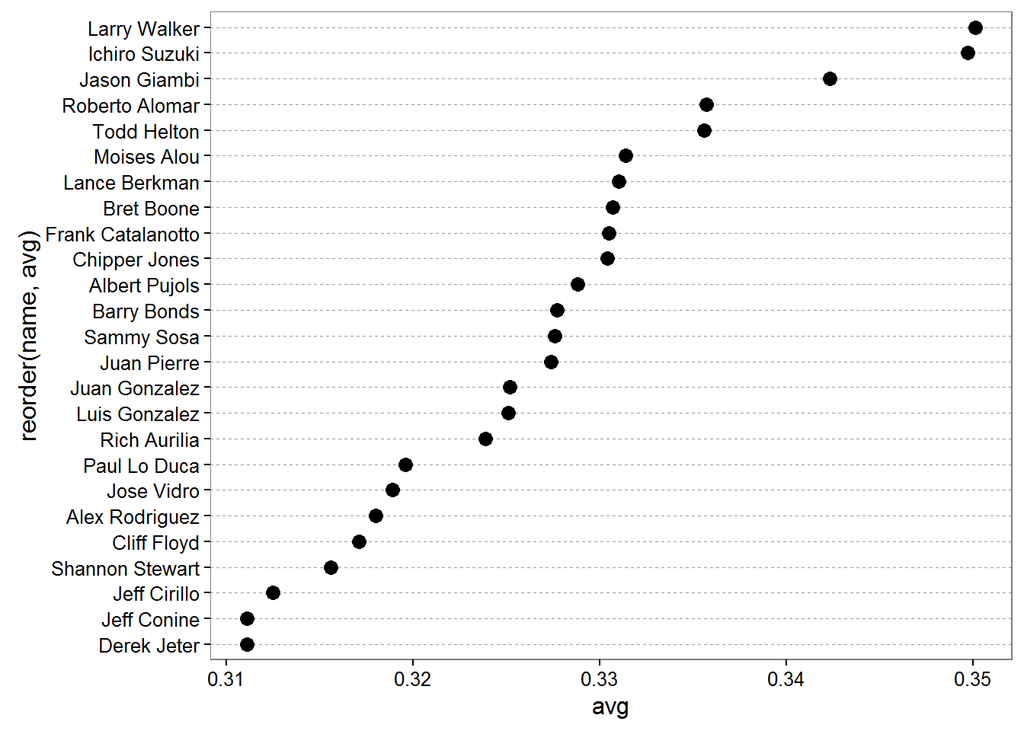

```r
ggplot(tophit, aes(x=avg, y=reorder(name, avg))) +
geom_point(size=3) + # Use a larger dot
theme_bw() +
theme(panel.grid.major.x = element_blank(),
panel.grid.minor.x = element_blank(),
panel.grid.major.y = element_line(colour="grey60", linetype="dashed"))
```

```r
# Comment: using the reorder() fucntion to reoder the name.
```

We want to rotate this chart let name in the x axis and avg in the y axis.

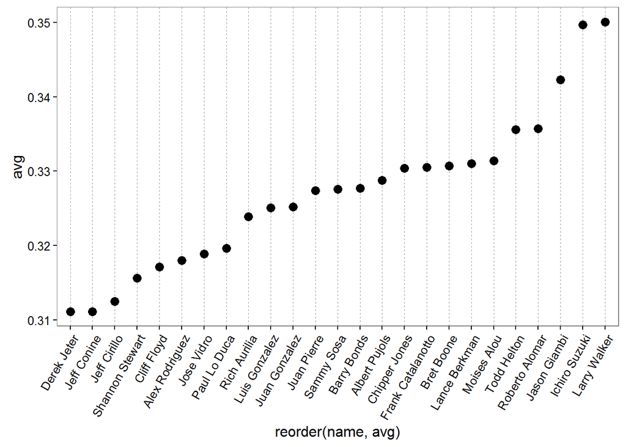

```r
ggplot(tophit, aes(x=reorder(name, avg), y=avg)) +
geom_point(size=3) + # Use a larger dot
theme_bw() +
theme(axis.text.x = element_text(angle=60, hjust=1),
panel.grid.major.y = element_blank(),
panel.grid.minor.y = element_blank(),
panel.grid.major.x = element_line(colour="grey60", linetype="dashed"))
```

We want to create a Cleveland Dot plot with divied by to group or factor of lg and also order by avg value.

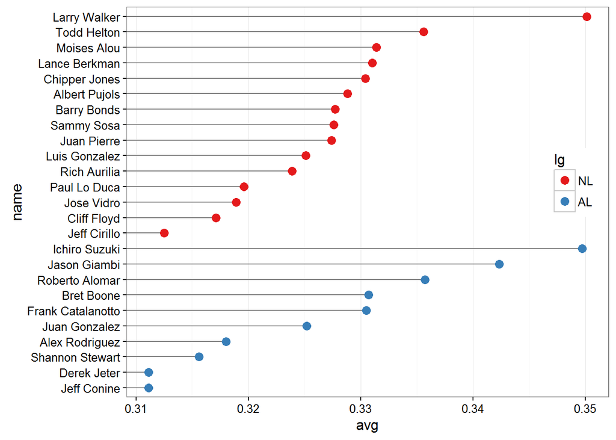

```r
# Create nameorder to index for name in the data set.
nameorder <- tophit$name[order(tophit$lg, tophit$avg)]
#change the name column into factor and also reorder it by nameorder
tophit$name <- factor(tophit$name, levels=nameorder)
ggplot(tophit, aes(x=avg, y=name)) +
geom_segment(aes(yend=name), xend=0, colour="grey50") +
geom_point(size=3, aes(colour=lg)) +
scale_colour_brewer(palette="Set1", limits=c("NL","AL")) +
theme_bw() +
theme(panel.grid.major.y = element_blank(), # No horizontal grid lines
legend.position=c(1, 0.55), # Put legend inside plot area
legend.justification=c(1, 0.5))
```

```r
# Comment: using geom_segment(aes(yend=name), xend=0, colour="grey50")
# to replace grid line.
```

We want to change lg label in to facet_grid.

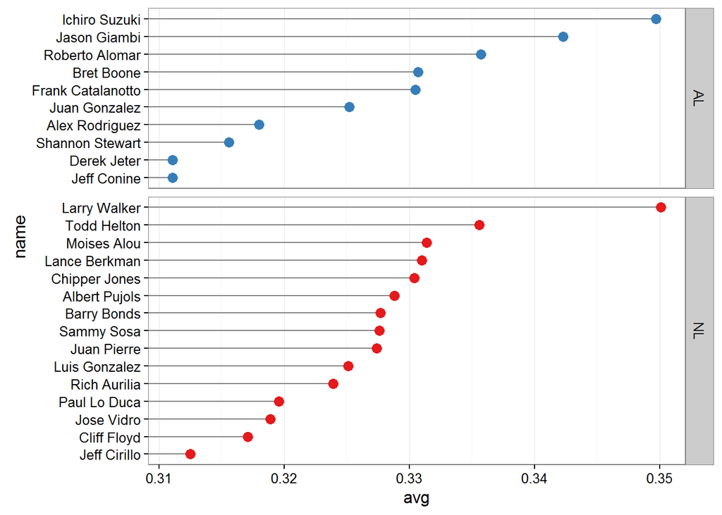

```r
ggplot(tophit, aes(x=avg, y=name)) +
geom_segment(aes(yend=name), xend=0, colour="grey50") +
geom_point(size=3, aes(colour=lg)) +
scale_colour_brewer(palette="Set1", limits=c("NL","AL"), guide=FALSE) +
theme_bw() +
theme(panel.grid.major.y = element_blank()) +
facet_grid(lg ~ ., scales="free_y", space="free_y")
```